# The Ad Before the Show: What YouTube Throws at Us

## Introduction: Understanding YouTube Ad Experiences

This report analyzes YouTube ad patterns from data I collected during viewing sessions. I tracked the number of ads before videos, ad types (e.g., product, service), video categories (e.g., music, gaming), and whether I skipped or watched ads to find trends in ad targeting and viewer engagement. Data was gathered by observing YouTube ads over time. I used bar charts for ad type frequency, histograms for ad counts, and pie charts for skipping behavior to clearly show key patterns.

## Visualization 1: What Types of Ads Are We Seeing?

This section explores the prevalence of different categories of advertisements encountered by users. The data is visualized as a bar chart, which clearly shows the counts for each ad type, such as product advertisements, service advertisements, political campaigns, charity or non-profit messages, and instances where no ad appeared.

[figure not shown]

## Visualization 2: How Many Ads Do We Typically Encounter?

This visualization, a histogram, delves into the number of advertisements users typically see before their selected video begins. The chart displays the frequency distribution, showing how often users encounter zero, one, two, or more ads.

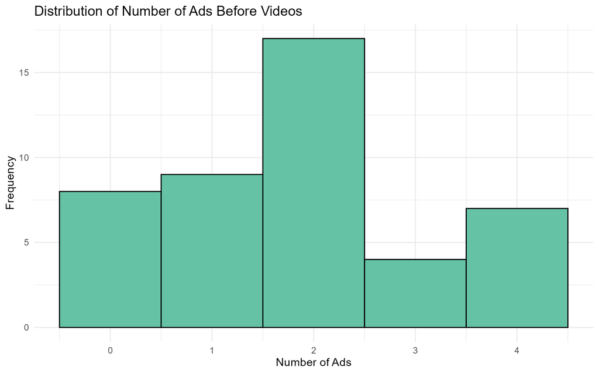

The histogram indicates that it is most common for users to see one or two advertisements before their video content plays. While some users encounter no ads, and others might see three or more, the bulk of experiences fall within the one-to-two ad range. This provides insight into the typical ad load on the platform and can be used to track if this load changes over time, potentially impacting user experience.

## Visualization 3: How Do Users Interact with Ads? A Look at Skipping Behaviour

This final visualization, presented as a pie chart, focuses on user engagement with YouTube ads, specifically their skipping behaviour. The chart segments represent different actions users take: skipping ads immediately, watching them partially, watching them completely, or encountering no ad at all.

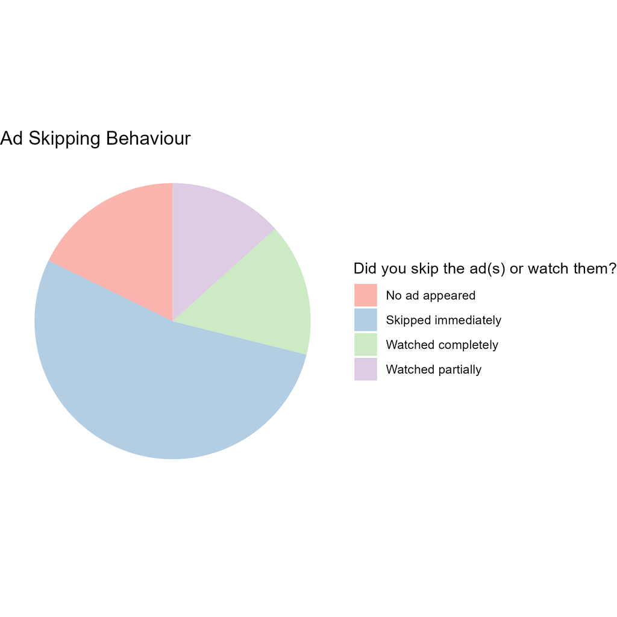

Pie chart representing YouTube ad skipping behaviour. The chart is divided into segments showing the proportion of ads skipped immediately, watched partially, watched completely, and instances where no ad appeared. A significant portion of users tend to skip ads immediately, which is the largest segment of the pie chart.

The pie chart clearly illustrates that a predominant user behaviour is to skip advertisements as soon as the option becomes available. While some users watch ads partially or completely, the segment representing immediate skips is typically the largest. This highlights a key challenge for advertisers in capturing audience attention within the first few seconds. The data also accounts for instances where no ad was presented, providing a complete picture of ad interaction scenarios.

This visual data story provides an overview of the key findings from the YouTube Ad Tracking survey, focusing on making the insights accessible through descriptive narratives and embedded visual data representations.